# analysis_polyA_vs_pseudo

Ariel Hippen

2022-07-31

# Analyzing differential expression results

We have calculated differential expression genes in DE_ribo_vs_polyA.Rmd, now we will try to make sense of them. Our main workhorse will be Gene Set Enrichment Analysis (GSEA) across several reference sets.

```r
suppressPackageStartupMessages({
  library(DESeq2)
  library(WebGestaltR)
  library(ggplot2)
})
```

```r
# Load the DESeq2 object with the original count matrix
dds <- readRDS("polyA_vs_pseudo_data.rds")

# Load the DESeqResults object with differentially expressed genes, at FDR 0.1 and 0.05
res1 <- readRDS("polyA_vs_pseudo_FDR_0.1.rds")
res05 <- readRDS("polyA_vs_pseudo_FDR_0.05.rds")
```

## Top genes

Let’s look at the top 20 most upregulated and downregulated genes and see if we can find a pattern.

```r
res1 <- subset(res1, res1$padj < 0.1)
res1 <- res1[order(res1$log2FoldChange), ]
as.data.frame(head(res1, n=20))
```

```
##              baseMean log2FoldChange     lfcSE       stat       pvalue
## AC021683.1   77.71972      -9.124608 0.7773809 -11.737628 8.174727e-32
## AC000123.1   55.41644      -9.092584 0.8279094 -10.982583 4.634806e-28
## SPDYE2       58.02264      -8.755596 0.7635293 -11.467270 1.926402e-30
## AC011510.1   43.79515      -8.612049 0.8060141 -10.684738 1.199873e-26
## LAMC1-AS1    88.99380      -8.417504 0.6859072 -12.272075 1.279317e-34
## AC018695.4   47.07899      -8.158881 0.8243371  -9.897505 4.267875e-23
## LIMS1-AS1    55.10452      -8.062321 0.7502046 -10.746829 6.133378e-27
## AC005104.1   28.90711      -7.735551 0.7924426  -9.761654 1.644503e-22
## AF235103.1   31.42331      -7.668113 0.8043718  -9.533046 1.527353e-21
## NPIPA9      104.68162      -7.636107 0.5730860 -13.324538 1.666605e-40
## AC131953.1   19.47953      -7.564077 0.8537570  -8.859754 8.019099e-19
## LINC02637    18.75356      -7.510205 0.8625043  -8.707441 3.108130e-18
## FAM217A      46.17725      -7.455598 0.7248484 -10.285733 8.171755e-25
## AL139349.1   28.67531      -7.405529 0.7954377  -9.310004 1.278272e-20
## IGHJ3P       34.04624      -7.358105 0.8567464  -8.588429 8.816673e-18
## AC005884.2   26.25358      -7.264912 0.7745786  -9.379180 6.648810e-21
## AC091685.1   15.47601      -7.171557 0.9022737  -7.948317 1.890629e-15
## ETV5-AS1     23.82578      -7.156903 0.7850709  -9.116250 7.776839e-20
## AC006116.10  51.78297      -7.121564 0.6065836 -11.740451 7.906387e-32
## AC074050.3  111.46294      -7.118139 0.4740183 -15.016592 5.717285e-51
##                     padj
## AC021683.1  1.004907e-30
## AC000123.1  4.930445e-27
## SPDYE2      2.256402e-29
## AC011510.1  1.195907e-25
## LAMC1-AS1   1.765004e-33
## AC018695.4  3.604580e-22
## LIMS1-AS1   6.194586e-26
## AC005104.1  1.347708e-21
## AF235103.1  1.195981e-20
## NPIPA9      2.898853e-39
## AC131953.1  5.410512e-18
## LINC02637   2.028970e-17
## FAM217A     7.523106e-24
## AL139349.1  9.558579e-20
## IGHJ3P      5.584019e-17
## AC005884.2  5.056244e-20
## AC091685.1  1.052399e-14
## ETV5-AS1    5.566024e-19
## AC006116.10 9.731344e-31
## AC074050.3  1.391740e-49
```

Reminder, these ^ are the ones that are much more expressed in true bulk than in pseudobulk. This looks like a lot of lncRNAs. None of the genes jump out as significant (except for maybe the immunoglobulin gene IHGJ3P).

```r
as.data.frame(tail(res1, n=20))
```

```
##                baseMean log2FoldChange     lfcSE     stat        pvalue
## AC090617.10    84.47290       9.821318 0.7819183 12.56054  3.479358e-36
## LINC02591     170.85351       9.873900 0.7469922 13.21821  6.888409e-40
## AC099518.5     89.32868       9.949519 0.7747414 12.84237  9.491976e-38
## AP005329.3    101.06915      10.146433 0.7815331 12.98273  1.533151e-38
## AC108863.2    118.71821      10.315873 0.7781969 13.25612  4.158471e-40
## HIST1H4C     6732.34693      10.462323 0.4904931 21.33021 5.953742e-101
## DDT          5273.82882      10.515235 0.3408329 30.85158 5.334354e-209
## AC005921.2    137.06047      10.530416 0.7811572 13.48053  2.036293e-41
## AL391121.1    173.74211      10.890651 0.7677606 14.18496  1.135360e-45
## AC092069.1    205.52800      11.026406 0.7681610 14.35429  1.001452e-46
## HIST1H2AK     301.82082      11.418801 0.7604047 15.01674  5.704402e-51
## SFT2D3        253.28650      11.487634 0.7645293 15.02576  4.978642e-51
## AL133453.1    390.13134      12.078650 0.7589054 15.91588  4.916864e-57
## AC087190.1    491.31234      12.312093 0.7757858 15.87048  1.014614e-56
## HYI           651.99859      12.787017 0.7631723 16.75509  5.198618e-63
## AC020656.1   1379.62202      13.564191 0.7691168 17.63606  1.302295e-69
## ZNF593       1373.68781      13.927586 0.7444453 18.70868  4.206935e-78
## EVA1B        1573.72792      13.958687 0.7546403 18.49714  2.177288e-76
## C19orf33     5644.18994      15.677243 0.7682368 20.40679  1.455479e-92
## MIF         36638.63789      17.939680 0.7618041 23.54894 1.287124e-122
##                      padj
## AC090617.10  5.102829e-35
## LINC02591    1.174647e-38
## AC099518.5   1.490472e-36
## AP005329.3   2.503187e-37
## AC108863.2   7.136535e-39
## HIST1H4C     4.488393e-99
## DDT         2.284650e-206
## AC005921.2   3.673781e-40
## AL391121.1   2.367830e-44
## AC092069.1   2.149230e-45
## HIST1H2AK    1.389748e-49
## SFT2D3       1.218963e-49
## AL133453.1   1.437222e-55
## AC087190.1   2.939594e-55
## HYI          1.778120e-61
## AC020656.1   5.145111e-68
## ZNF593       2.021518e-76
## EVA1B        1.013279e-74
## C19orf33     9.411884e-91
## MIF         1.435361e-120
```

These ^ are the genes that are much more expressed in pseudobulk than true bulk. There are two histone genes, which I find interesting. I’m also interested that there’s more MIF and DDT, which are apparently closely related inflammatory cytokines. It could be a coincidence though if there just happened to be more macrophages in that set.

## GSEA

WebGestaltR expects a data frame with two columns, gene name and fold change.

```r
res1$gene <- rownames(res1); rownames(res1) <- NULL
res1 <- subset(res1, select=c("gene","log2FoldChange"))
res1 <- as.data.frame(res1)
nrow(res1)
```

```
## [1] 20121
```

```r
res05 <- subset(res05, res05$padj < 0.05)
res05$gene <- rownames(res05); rownames(res05) <- NULL
res05 <- subset(res05, select=c("gene","log2FoldChange"))
res05 <- as.data.frame(res05)
nrow(res05)
```

```
## [1] 18721
```

### GO Biological process

Our first try at GSEA will use the same reference set we used for overrepresentation analysis in the single-cell data, GO Biological process.

```r
GO_bp <- suppressWarnings(WebGestaltR(enrichMethod = "GSEA",
                          enrichDatabase = "geneontology_Biological_Process_noRedundant",
                          interestGene = res1,
                          interestGeneType = "genesymbol",
                          isOutput = FALSE))
```

```
## Loading the functional categories...
## Loading the ID list...
## Performing the enrichment analysis...
## 1000 permutations of score complete...
```

```r
nrow(GO_bp)
```

```
## [1] 143
```

```r
GO_bp <- GO_bp[order(GO_bp$normalizedEnrichmentScore, decreasing = TRUE),]
head(subset(GO_bp, select=c("geneSet","description","normalizedEnrichmentScore","pValue","FDR","size")))
```

```
##      geneSet                                      description
## 1 GO:0070972    protein localization to endoplasmic reticulum
## 2 GO:0033108 mitochondrial respiratory chain complex assembly
## 3 GO:0010257              NADH dehydrogenase complex assembly
## 4 GO:0006413                         translational initiation
## 5 GO:0140053                    mitochondrial gene expression
## 6 GO:0017004                      cytochrome complex assembly
##   normalizedEnrichmentScore pValue FDR size
## 1                  3.442658      0   0  125
## 2                  3.263263      0   0   83
## 3                  3.061042      0   0   51
## 4                  3.050137      0   0  164
## 5                  2.688615      0   0  141
## 6                  2.672021      0   0   31
```

```r
tail(subset(GO_bp, select=c("geneSet","description","normalizedEnrichmentScore","pValue","FDR","size")))
```

```
##       geneSet                                               description
## 16 GO:0097485                                neuron projection guidance
## 18 GO:0071526                       semaphorin-plexin signaling pathway
## 19 GO:0098742 cell-cell adhesion via plasma-membrane adhesion molecules
## 20 GO:0035249                      synaptic transmission, glutamatergic
## 12 GO:0006814                                      sodium ion transport
## 13 GO:0043062                      extracellular structure organization
##    normalizedEnrichmentScore pValue          FDR size
## 16                 -2.285921      0 0.0002474975  183
## 18                 -2.317182      0 0.0002969970   34
## 19                 -2.323752      0 0.0003712462  177
## 20                 -2.329432      0 0.0004949950   59
## 12                 -2.379232      0 0.0000000000  138
## 13                 -2.572898      0 0.0000000000  292
```

```r
GO_bp_05 <- suppressWarnings(WebGestaltR(enrichMethod = "GSEA",
                             enrichDatabase = "geneontology_Biological_Process_noRedundant",
                             interestGene = res05,
                             interestGeneType = "genesymbol",
                             isOutput = FALSE))
```

```
## Loading the functional categories...
## Loading the ID list...
## Performing the enrichment analysis...
## 1000 permutations of score complete...
```

```r
nrow(GO_bp_05)
```

```
## [1] 148
```

```r
GO_bp_05 <- GO_bp_05[order(GO_bp_05$normalizedEnrichmentScore, decreasing = TRUE),]
head(subset(GO_bp_05, select=c("geneSet","description","normalizedEnrichmentScore","pValue","FDR","size")))
```

```
##      geneSet                                      description
## 1 GO:0070972    protein localization to endoplasmic reticulum
## 2 GO:0033108 mitochondrial respiratory chain complex assembly
## 3 GO:0010257              NADH dehydrogenase complex assembly
## 4 GO:0006413                         translational initiation
## 5 GO:0017004                      cytochrome complex assembly
## 6 GO:0140053                    mitochondrial gene expression
##   normalizedEnrichmentScore pValue FDR size
## 1                  3.392701      0   0  124
## 2                  3.307704      0   0   82
## 3                  3.096544      0   0   51
## 4                  3.000916      0   0  163
## 5                  2.715056      0   0   30
## 6                  2.693563      0   0  137
```

```r
tail(subset(GO_bp_05, select=c("geneSet","description","normalizedEnrichmentScore","pValue","FDR","size")))
```

```
##       geneSet                                               description
## 17 GO:0071526                       semaphorin-plexin signaling pathway
## 19 GO:0035249                      synaptic transmission, glutamatergic
## 15 GO:0006814                                      sodium ion transport
## 18 GO:0097485                                neuron projection guidance
## 20 GO:0098742 cell-cell adhesion via plasma-membrane adhesion molecules
## 11 GO:0043062                      extracellular structure organization
##    normalizedEnrichmentScore pValue          FDR size
## 17                 -2.325421      0 0.0005018696   33
## 19                 -2.338812      0 0.0006022435   58
## 15                 -2.350223      0 0.0003764022  130
## 18                 -2.365621      0 0.0005018696  175
## 20                 -2.369736      0 0.0007528044  166
## 11                 -2.574968      0 0.0000000000  281
```

### GO Cellular Component

```r
GO_cc <- suppressWarnings(WebGestaltR(enrichMethod = "GSEA",
                             enrichDatabase = "geneontology_Cellular_Component_noRedundant",
                             interestGene = res05,
                             interestGeneType = "genesymbol",
                             isOutput = FALSE))
```

```
## Loading the functional categories...
## Loading the ID list...
## Performing the enrichment analysis...
## 1000 permutations of score complete...
```

```r
nrow(GO_cc)
```

```
## [1] 49
```

```r
GO_cc <- GO_cc[order(GO_cc$normalizedEnrichmentScore, decreasing = TRUE),]
head(subset(GO_cc, select=c("geneSet","description","normalizedEnrichmentScore","pValue","FDR","size")))
```

```
##      geneSet                   description normalizedEnrichmentScore pValue FDR
## 1 GO:0005840                      ribosome                  3.724768      0   0
## 2 GO:0098798 mitochondrial protein complex                  3.514858      0   0
## 3 GO:0070469             respiratory chain                  3.444232      0   0
## 4 GO:0030964    NADH dehydrogenase complex                  3.184366      0   0
## 5 GO:0005743  mitochondrial inner membrane                  3.116713      0   0
## 6 GO:0044455   mitochondrial membrane part                  3.096985      0   0
##   size
## 1  209
## 2  227
## 3   77
## 4   41
## 5  358
## 6  187
```

```r
tail(subset(GO_cc, select=c("geneSet","description","normalizedEnrichmentScore","pValue","FDR","size")))
```

```
##       geneSet                 description normalizedEnrichmentScore pValue FDR
## 11 GO:0097060           synaptic membrane                 -2.229547      0   0
## 12 GO:0016323 basolateral plasma membrane                 -2.289107      0   0
## 13 GO:0045177         apical part of cell                 -2.342157      0   0
## 14 GO:0031253    cell projection membrane                 -2.409296      0   0
## 15 GO:0031012        extracellular matrix                 -2.438633      0   0
## 16 GO:0005581             collagen trimer                 -2.538988      0   0
##    size
## 11  269
## 12  151
## 13  250
## 14  230
## 15  327
## 16   60
```

```r
GO_cc_05 <- suppressWarnings(WebGestaltR(enrichMethod = "GSEA",
                             enrichDatabase = "geneontology_Cellular_Component_noRedundant",
                             interestGene = res05,
                             interestGeneType = "genesymbol",
                             isOutput = FALSE))
```

```
## Loading the functional categories...
## Loading the ID list...
## Performing the enrichment analysis...
## 1000 permutations of score complete...
```

```r
nrow(GO_cc_05)
```

```
## [1] 50
```

```r
GO_cc_05 <- GO_cc_05[order(GO_cc_05$normalizedEnrichmentScore, decreasing = TRUE),]
head(subset(GO_cc_05, select=c("geneSet","description","normalizedEnrichmentScore","pValue","FDR","size")))
```

```
##      geneSet                   description normalizedEnrichmentScore pValue FDR
## 1 GO:0005840                      ribosome                  3.686566      0   0
## 2 GO:0098798 mitochondrial protein complex                  3.563520      0   0
## 3 GO:0070469             respiratory chain                  3.467978      0   0
## 4 GO:0005743  mitochondrial inner membrane                  3.152831      0   0
## 5 GO:0030964    NADH dehydrogenase complex                  3.132493      0   0
## 6 GO:0044455   mitochondrial membrane part                  3.119605      0   0
##   size
## 1  209
## 2  227
## 3   77
## 4  358
## 5   41
## 6  187
```

```r
tail(subset(GO_cc_05, select=c("geneSet","description","normalizedEnrichmentScore","pValue","FDR","size")))
```

```
##       geneSet                 description normalizedEnrichmentScore pValue
## 21 GO:0097060           synaptic membrane                 -2.209459      0
## 13 GO:0016323 basolateral plasma membrane                 -2.275310      0
## 14 GO:0045177         apical part of cell                 -2.345300      0
## 15 GO:0031253    cell projection membrane                 -2.367280      0
## 16 GO:0031012        extracellular matrix                 -2.453515      0
## 17 GO:0005581             collagen trimer                 -2.563711      0
##             FDR size
## 21 0.0002347843  269
## 13 0.0000000000  151
## 14 0.0000000000  250
## 15 0.0000000000  230
## 16 0.0000000000  327
## 17 0.0000000000   60
```

### Cell types

Let’s try a custom set for cell types, as curated by the folks at http://www.gsea-msigdb.org/

```r
C8 <- suppressWarnings(WebGestaltR(enrichMethod = "GSEA",
                       enrichDatabaseFile = "GSEA_custom_sets/c8.all.v7.5.1.symbols.gmt",
                       enrichDatabaseType = "genesymbol",
                       interestGene = res1,
                       interestGeneType = "genesymbol",
                       isOutput = FALSE))
```

```
## Loading the functional categories...
## Loading the ID list...
## Performing the enrichment analysis...
## 1000 permutations of score complete...
```

```r
nrow(C8)
```

```
## [1] 250
```

```r
C8 <- C8[order(C8$normalizedEnrichmentScore, decreasing = TRUE),]
head(subset(C8, select=c("geneSet","normalizedEnrichmentScore","pValue","FDR","size")))
```

```
##                                                geneSet
## 1                   RUBENSTEIN_SKELETAL_MUSCLE_T_CELLS
## 2 FAN_OVARY_CL10_PUTATIVE_EARLY_ATRESIA_GRANULOSA_CELL
## 3         BUSSLINGER_DUODENAL_TRANSIT_AMPLIFYING_CELLS
## 4                   RUBENSTEIN_SKELETAL_MUSCLE_B_CELLS
## 5           RUBENSTEIN_SKELETAL_MUSCLE_SATELLITE_CELLS
## 6                  RUBENSTEIN_SKELETAL_MUSCLE_NK_CELLS
##   normalizedEnrichmentScore pValue FDR size
## 1                  3.895505      0   0  170
## 2                  3.746834      0   0  257
## 3                  3.702385      0   0  173
## 4                  3.700736      0   0  157
## 5                  3.683401      0   0  263
## 6                  3.650464      0   0  193
```

```r
tail(subset(C8, select=c("geneSet","normalizedEnrichmentScore","pValue","FDR","size")))
```

```
##                                              geneSet normalizedEnrichmentScore
## 96        DESCARTES_FETAL_MUSCLE_SMOOTH_MUSCLE_CELLS                 -2.479765
## 97                        AIZARANI_LIVER_C13_LSECS_2                 -2.491457
## 98         GAO_LARGE_INTESTINE_ADULT_CJ_IMMUNE_CELLS                 -2.504142
## 99  DESCARTES_FETAL_LIVER_VASCULAR_ENDOTHELIAL_CELLS                 -2.514120
## 100             DESCARTES_FETAL_LIVER_STELLATE_CELLS                 -2.523688
## 101                       AIZARANI_LIVER_C10_MVECS_1                 -2.573392
##     pValue FDR size
## 96       0   0   50
## 97       0   0  228
## 98       0   0  373
## 99       0   0   97
## 100      0   0   96
## 101      0   0  212
```

```r
C8_05 <- suppressWarnings(WebGestaltR(enrichMethod = "GSEA",
                       enrichDatabaseFile = "GSEA_custom_sets/c8.all.v7.5.1.symbols.gmt",
                       enrichDatabaseType = "genesymbol",
                       interestGene = res05,
                       interestGeneType = "genesymbol",
                       isOutput = FALSE))
```

```
## Loading the functional categories...
## Loading the ID list...
## Performing the enrichment analysis...
## 1000 permutations of score complete...
```

```r
nrow(C8_05)
```

```
## [1] 259
```

```r
C8_05 <- C8_05[order(C8_05$normalizedEnrichmentScore, decreasing = TRUE),]
head(subset(C8_05, select=c("geneSet","normalizedEnrichmentScore","pValue","FDR","size")))
```

```
##                                                geneSet
## 1                   RUBENSTEIN_SKELETAL_MUSCLE_T_CELLS
## 2 FAN_OVARY_CL10_PUTATIVE_EARLY_ATRESIA_GRANULOSA_CELL
## 3                   RUBENSTEIN_SKELETAL_MUSCLE_B_CELLS
## 4           RUBENSTEIN_SKELETAL_MUSCLE_SATELLITE_CELLS
## 5                  RUBENSTEIN_SKELETAL_MUSCLE_NK_CELLS
## 6         BUSSLINGER_DUODENAL_TRANSIT_AMPLIFYING_CELLS
##   normalizedEnrichmentScore pValue FDR size
## 1                  3.953852      0   0  169
## 2                  3.791115      0   0  254
## 3                  3.745290      0   0  156
## 4                  3.711520      0   0  257
## 5                  3.698322      0   0  190
## 6                  3.693884      0   0  172
```

```r
tail(subset(C8_05, select=c("geneSet","normalizedEnrichmentScore","pValue","FDR","size")))
```

```
##                                             geneSet normalizedEnrichmentScore
## 93             DESCARTES_FETAL_LIVER_STELLATE_CELLS                 -2.549629
## 94 DESCARTES_FETAL_LIVER_VASCULAR_ENDOTHELIAL_CELLS                 -2.555029
## 95        GAO_LARGE_INTESTINE_ADULT_CJ_IMMUNE_CELLS                 -2.562111
## 96                       AIZARANI_LIVER_C13_LSECS_2                 -2.585439
## 97       DESCARTES_FETAL_MUSCLE_SMOOTH_MUSCLE_CELLS                 -2.599788
## 98                       AIZARANI_LIVER_C10_MVECS_1                 -2.608344
##    pValue FDR size
## 93      0   0   91
## 94      0   0   90
## 95      0   0  354
## 96      0   0  217
## 97      0   0   46
## 98      0   0  205
```

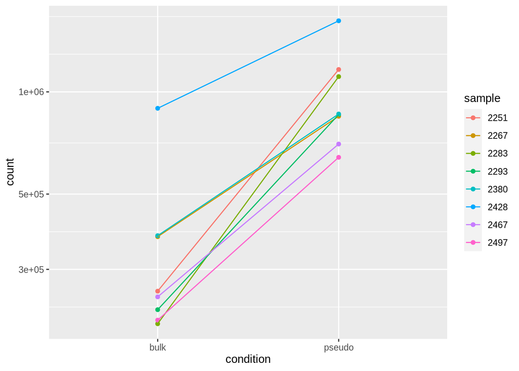

```r
gene <- "MT-ATP6"
d <- plotCounts(dds, gene=gene, intgroup=c("condition","sample"), returnData=TRUE)
ggplot(d, aes(x=condition, y=count, group=sample, color=sample)) +
  geom_point() + scale_y_log10() + geom_line()
```